# **Quality Indicators Framework**

The Quality Indicators (QI) module is meant to take place right after a statistical process has been validated. This means that a technical unit has already finalized its entire data processing (**questionnaire dispatch $\Rightarrow$ data collection $\Rightarrow$ data entry $\Rightarrow$ data cleaning $\Rightarrow$ imputation $\Rightarrow$ validation**) and it is ready to release the data. Thus, the *officer in charge* can analyse the quality of the data before disseminating and may return to any step of the process if he/she deems necessary.

The workflow of the QI module is shown below. As mentioned above, it starts when the data is ready to be released. In the SWS context, this means that the technical unit can *tag* its data set and materialize it in the SWS domain **Disseminated Datasets**. Therefore, the **faoswsQualityIndicators** module can compile the indicators and save them in a dedicated dataset in the domain **Quality Indicators**. In this way, the *officer in charge* can find the results either in the SWS or in the *Shiny App*.

It is important to highlight that each technical unit is responsible for its own data in the domain **Disseminated Datasets**, which means that the technical unit is the only one who is able to populate/modify its own data.

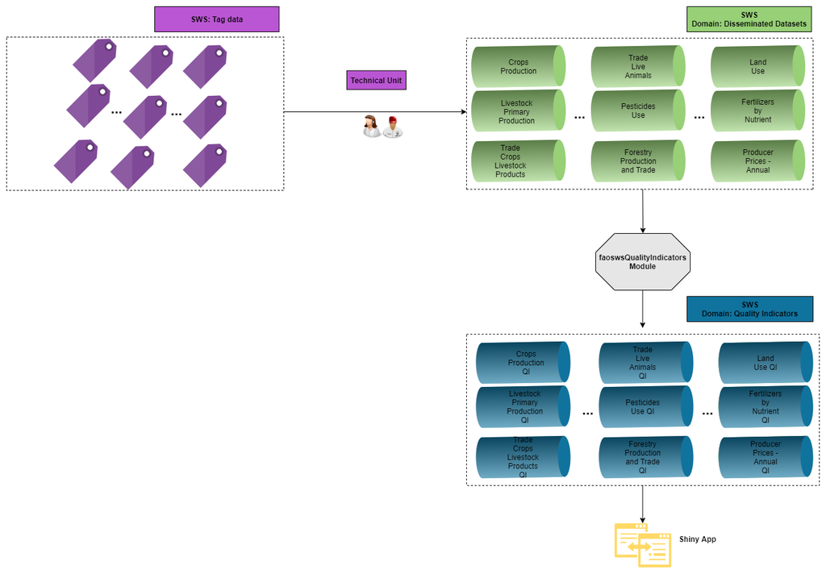

Overall Workflow of the Quality Indicators module in the SWS

## **Build up historical data disseminated in the SWS**

It is known that the SWS was built to be a working system and not a dissemination platform. This means that unless a technical unit creates a dedicated data set to store only the dissemination data, this data will be found only in the dissemination platform because as time passes, the data may be revised or another imputation method tested and not necessarily be disseminated for various reasons. Thus, there might be differences between the data found in the two systems.

Despite this issue, it is still worth to compute the QI for the historical data disseminated. In order to do so, the CSI-SWS team had to retrieve the data from the dissemination platforms (e.g. FAOSTAT) and bring it back to the SWS for the technical units that did not create the *data dissemination*. This exercise is illustrated in the below figure.

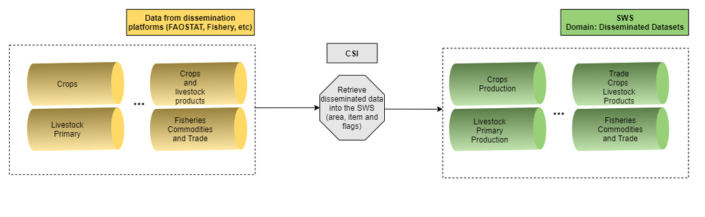

Workflow to retrieve historical data disseminated

For each disseminated data to be migrated to SWS there is a need to convert:

- areas to `geographicAreaM49`;
- items to `measuredItemCPC` (or another code list that contains those items);
- elements to `measuredElement` (or another code list that contains those elements);
- flags to SWS flag system (`flagObservationStatus` and `flagMethod`).

Converting areas, items and elements from one system to another one is usually straightforward. However, the flag conversion is possible only from SWS to FAOSTAT. The other way round is not feasible as there is no one-to-one correspondence. Therefore the only way to retrieve the flags is, given a combination country-element-item-year-value disseminated, convert areas, items and elements to the SWS format and searches for it in the SWS - including in the historical data. The two data points should match exactly in terms of values for that year. Thus one can find the SWS flag system. If the values in both systems do not match, the algorithm takes the most recent figure with its flags.

## **Statistical Outputs**

FAO is responsible for the dissemination of several statistical outputs including data on agriculture production and trade, forestry, fisheries, fertilizers, pesticides, producer prices and others. Along with the data, it is also important for transparency purposes to release information regarding its quality. Thus this book describes in details the process to compile the QI for each of these outputs, as they are composed of differents kinds of elements, items and areas. Moreover, each statistical process may have its own data processing, from harvesting to storage, with peculiarities that need to be taken into consideration when calculating the QI.

### **Crops**

[*Crops*](http://www.fao.org/faostat/en/#data/QC) are disseminated in **FAOSTAT** under **Production**. In order to calculate their QI, there was a need to build up the historical data disseminated as described in **Build up historical data disseminated in the SWS**. Its correspondent data set in the SWS is in the domain `agriculture`, data set `aproduction`.

### **Livestock Primary**

[*Livestock Primary*](http://www.fao.org/faostat/en/#data/QL) is disseminated in **FAOSTAT** under **Production**. In order to calculate their QI, there was a need to build up the historical data disseminated as described in **Build up historical data disseminated in the SWS**. Its correspondent data set in the SWS is in the domain `agriculture`, data set `aproduction`.

### **Crops and livestock products**

[*Crops and livestock products*](http://www.fao.org/faostat/en/#data/TP) are disseminated in **FAOSTAT** under **Trade**. In order to calculate their QI, there was a need to build up the historical data disseminated as described in **Build up historical data disseminated in the SWS**. Its correspondent data set in the SWS is in the domain `trade`, data set `total_trade_cpc_m49`.

### **Live animals**

[*Live animals*](http://www.fao.org/faostat/en/#data/TA) are disseminated in **FAOSTAT** under **Trade**. In order to calculate their QI, there was a need to build up the historical data disseminated as described in **Build up historical data disseminated in the SWS**. Its correspondent data set in the SWS is in the domain `trade`, data set `total_trade_cpc_m49`.

### **Fertilizers by Nutrient**

[*Fertilizers by Nutrient*](http://www.fao.org/faostat/en/#data/RFN) are disseminated in **FAOSTAT** under **Inputs**. The *Environment Team* responsible for this output has already created a dedicated dissemination data set called **Fertilizers (dissemination)** in the SWS to store the data. Therefore, there was a need to make a *copy* of it into the domain *Disseminated Datasets*.

### **Fertilizers by Product**

[*Fertilizers by Product*](http://www.fao.org/faostat/en/#data/RFB) are disseminated in **FAOSTAT** under **Inputs**. The *Environment Team* responsible for this output has already created a dedicated dissemination data set called **Fertilizers (dissemination)** in the SWS to store the data. Therefore, there was a need to make a *copy* of it into the domain *Disseminated Datasets*.

### **Forestry Production and Trade**

[*Forestry Production and Trade*](http://www.fao.org/faostat/en/#data/FO) are disseminated in **FAOSTAT** under **Forestry**. In order to calculate their QI, there was a need to build up the historical data disseminated as described in **Build up historical data disseminated in the SWS**. Its correspondent data set in the SWS is in the domain `Forestry`, data set `forestry_prod_trade_agg_diss`.

### **Aquaculture Production**

[*Aquaculture Production*](http://www.fao.org/fishery/statistics/software/fishstatj/en) are disseminated through the Windows and Mac application **FishStatJ**. In the domain *Disseminated Datasets*, its data set is **Aquaculture Production Disseminated**.

### **Capture Production**

[*Capture Production*](http://www.fao.org/fishery/statistics/software/fishstatj/en) are disseminated through the Windows and Mac application **FishStatJ**. In the domain *Disseminated Datasets*, its data set is **Capture Production Disseminated**.

### **Producer Prices**

[*Producer Prices*](http://www.fao.org/faostat/en/#data/PP) are disseminated in **FAOSTAT** under **Prices**. The disseminated data set in the domain *Disseminated Datasets* is **Annual Producer Prices (Validation) - Diss**.

### **Pesticides Use**

[*Pesticides Use*](http://www.fao.org/faostat/en/#data/RP) are disseminated in **FAOSTAT** under **Inputs**. The *Environment Team* responsible for this output has already created a dedicated dissemination data set called **Pesticides Use (dissemination)** in the SWS to store the data. Therefore, there was a need to make a *copy* of it into the domain *Disseminated Datasets*.

### **Pesticides Trade**

[*Pesticides Trade*](http://www.fao.org/faostat/en/#data/RT) are disseminated in **FAOSTAT** under **Inputs**. The *Environment Team* responsible for this output has already created a dedicated dissemination data set called **Pesticides Trade (dissemination)** in the SWS to store the data. Therefore, there was a need to make a *copy* of it into the domain *Disseminated Datasets*.

### **Land Use**

[*Land Use*](http://www.fao.org/faostat/en/#data/RL) are disseminated in **FAOSTAT** under **Inputs**. The *Environment Team* responsible for this output has already created a dedicated dissemination data set called **Land Use (dissemination)** in the SWS to store the data. Therefore, there was a need to make a *copy* of it into the domain *Disseminated Datasets*.

## **Create and Transfer tags**

The tagged data plays a role in the Quality Indicators workflow. Meant to be created in the dissemination phase, when the data cycle has completed, the tags (or tagged data) are accessed through an API to be later published in a dissemination platform (e.g. [FAOSTAT](http://www.fao.org/faostat/en/#home)).

It is worth highlighting to the technical units that the quality indicators have as **input data** the data set stored in the domain **Disseminated Datasets** rather than the working data. Therefore, the tag creation and its transfer to the **Disseminated Datasets** are the first steps in order to calculate the quality indicators.

The example below shows how to:

- tag your data set: as you can see in the video below, you don’t need to create a session in order to tag the data. This example is with the domain `Forestry`, data set `forestry_prod_trade_agg`.

[video not shown]

- transfer tag to domain **Disseminated Datasets**: once the tag is created, you can transfer it as shown below.

[video not shown]